# Informe

## La millor defensa.

Volem analitzar quina podria ser la millor línia defensiva, tant tant per l'equip masculí com femení, a partir de les dades obtingudes de FIFA 2022 (female_players_22.csv i players_22.csv). En el projecte anomenat “European VetLeague”, competiran equips mixtos de jugadores/es a partir de 30 anys.Volem conéixer també quina podria ser la millor defensa formada per jugadors/es de qualsevol sexe que tinguin 30 anys o més.

1. Definició de “defensa”. Una línia defensiva es compon de 4 jugadors/es: 2 defenses centrals (CB segons la notació de la columna “player_positions”); 1 defensa lateral dret (RB); i 1 defensa lateral esquerre (LB).
2. Determinar quins jugadors poden jugar a cadascuna de les posicions d'interès.
3. Determinar totes les possibles línies defensives que s'hi puguin constituir.
4. Estimació de quina aportació produeix cada possible línia defensiva en els tres criteris següents:

   1) defensa;

   2) control de pilota (possessió);

   3) atac.

```python
import pandas as pd
import seaborn as sns
sns.set_palette("cool")
import matplotlib.pyplot as plt
plt.style.use('ggplot')
import numpy as np
import warnings
warnings.filterwarnings('ignore')
```

```python
df = pd.read_csv('data/players_22.csv', low_memory = False)
```

Assignem posicions principals a cada jugador:

```python
df['player_positions'].str.split().apply(lambda x: x[0]).unique()
```

```
array(['RW,', 'ST', 'ST,', 'LW,', 'CM,', 'GK', 'CDM,', 'CF,', 'LM,',
       'CDM', 'CB', 'LW', 'RW', 'CM', 'CAM', 'CAM,', 'CB,', 'LB', 'RB',
       'RM,', 'LB,', 'RB,', 'CF', 'LWB,', 'RWB,', 'RWB', 'LM', 'RM',
       'LWB'], dtype=object)
```

Assignarem uns pesos a cadascuna de les característiques, en funció de la seva aportació a les capacitats defensives.

pes mig/baix:

- *mentality_composure*
- *mentality_vision*
- *skill_long_passing*
- *movement_sprint_speed*

pes baix:

- *skill_ball_control*

Per un **defensa lateral**, les que tenen més pes són:

- *defending*
- *defending_standing_tackle*
- *defending_sliding_tackle*
- *movement_reactions*
- *movement_agility*

amb un pes mig/alt:

- *attacking_crossing*
- *skill_long_passing*
- *power_stamina*

pes mig/baix:

- *skill_ball_control*
- *attacking_short_passing*

pes baix:

- *dribbling*
- *defending_marking_awareness*
- *mentality_positioning*
- *attacking_finishing*

## Millor defensa equip masculí

El rànking de millors defensa **lateral dret** per l'equip masculí és:

```python
#weights
a = 0.5
b = 1
c= 2
d = 3

df['best_center_backs'] = (d*df.defending + c*df.mentality_interceptions +
                           d*df.defending_sliding_tackle + d*df.defending_standing_tackle +
                           b*df.mentality_vision + b*df.mentality_composure +
                           b*df.skill_curve + a*df.skill_ball_control+
                           b*df.skill_long_passing + c*df.movement_acceleration +
                           b*df.movement_sprint_speed + d*df.power_stamina +
                           d*df.power_jumping + b*df.power_long_shots +
                           d*df.defending_marking_awareness +
                           c*df.mentality_aggression)/(a + 6*b + 3*c + 6*d)

df['best_wb'] = (d*df.defending + b*df.skill_ball_control + a*df.dribbling +
                 a*df.defending_marking_awareness + d*df.defending_standing_tackle +
                 d*df.defending_sliding_tackle + a*df.mentality_positioning +
                 c*df.attacking_crossing + b*df.attacking_short_passing +
                 c*df.skill_long_passing + d*df.movement_reactions + d*df.movement_agility +
                 c*df.power_stamina + a*df.attacking_finishing)/(4*a + 2*b + 3*c + 5*d)
```

```python
# Best Right Wing Back Talents (RB, RWB)

wing_back_right = df[df.player_positions.str.contains('\\b(?:RB)|(?:RWB)\\b', regex=True)]

# Best Left Wing Back Talents (LB, LWB)

wing_back_left = df[df.player_positions.str.contains('\\b(?:LB)|(?:LWB)\\b', regex=True)]

# Best Centre Back Talents (CB)

center_back = df[df.player_positions.str.contains('CB')]
```

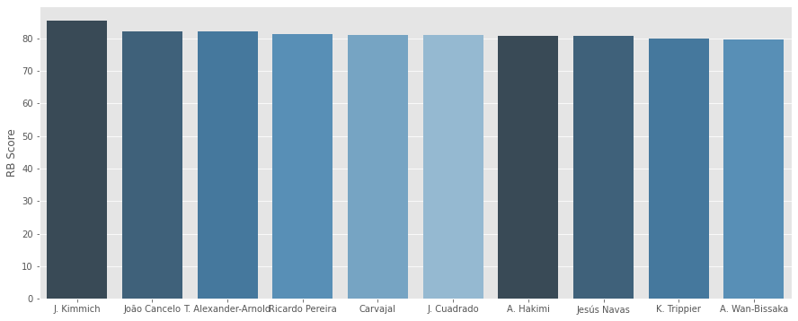

```python
#DEFENSOR LATERAL DRET:
plt.figure(figsize= (15,6))
sd = wing_back_right.sort_values('best_wb',ascending=False)[:10]
x2 = np.array(list(sd['short_name']))
y2 = np.array(list(sd['best_wb']))
sns.barplot(x2, y2, palette=sns.color_palette("Blues_d"))
plt.ylabel("RB Score")
```

```python
sd = sd.sort_values(['defending','skill_ball_control','attacking_crossing'],ascending=(False,False,False)).head(10)
sd
```

|  | sofifa_id | player_url | short_name | long_name | player_positions | overall | potential | value_eur | wage_eur | age | ... | rcb | rb | gk | player_face_url | club_logo_url | club_flag_url | nation_logo_url | nation_flag_url | best_center_backs | best_wb |
| --- | --- | --- | --- | --- | --- | --- | --- | --- | --- | --- | --- | --- | --- | --- | --- | --- | --- | --- | --- | --- | --- |
| 19 | 212622 | https://sofifa.com/player/212622/joshua-kimmic... | J. Kimmich | Joshua Walter Kimmich | CDM, RB | 89 | 90 | 108000000.0 | 160000.0 | 26 | ... | 81+3 | 83+3 | 21+3 | https://cdn.sofifa.net/players/212/622/22_120.png | https://cdn.sofifa.net/teams/21/60.png | https://cdn.sofifa.net/flags/de.png | https://cdn.sofifa.net/teams/1337/60.png | https://cdn.sofifa.net/flags/de.png | 83.655738 | 85.50 |
| 87 | 204963 | https://sofifa.com/player/204963/daniel-carvaj... | Carvajal | Daniel Carvajal Ramos | RB | 85 | 85 | 47500000.0 | 210000.0 | 29 | ... | 80+3 | 82+3 | 20+3 | https://cdn.sofifa.net/players/204/963/22_120.png | https://cdn.sofifa.net/teams/243/60.png | https://cdn.sofifa.net/flags/es.png | NaN | https://cdn.sofifa.net/flags/es.png | 80.213115 | 81.08 |
| 188 | 229880 | https://sofifa.com/player/229880/aaron-wan-bis... | A. Wan-Bissaka | Aaron Wan-Bissaka | RB | 83 | 87 | 48500000.0 | 115000.0 | 23 | ... | 78+2 | 81+2 | 16+2 | https://cdn.sofifa.net/players/229/880/22_120.png | https://cdn.sofifa.net/teams/11/60.png | https://cdn.sofifa.net/flags/gb-eng.png | NaN | https://cdn.sofifa.net/flags/gb-eng.png | 78.426230 | 79.74 |
| 44 | 231281 | https://sofifa.com/player/231281/trent-alexand... | T. Alexander-Arnold | Trent Alexander-Arnold | RB | 87 | 92 | 114000000.0 | 150000.0 | 22 | ... | 78+3 | 83+3 | 19+3 | https://cdn.sofifa.net/players/231/281/22_120.png | https://cdn.sofifa.net/teams/9/60.png | https://cdn.sofifa.net/flags/gb-eng.png | https://cdn.sofifa.net/teams/1318/60.png | https://cdn.sofifa.net/flags/gb-eng.png | 79.901639 | 82.06 |
| 62 | 210514 | https://sofifa.com/player/210514/joao-pedro-ca... | João Cancelo | João Pedro Cavaco Cancelo | RB, LB | 86 | 87 | 71500000.0 | 185000.0 | 27 | ... | 78+3 | 83+3 | 19+3 | https://cdn.sofifa.net/players/210/514/22_120.png | https://cdn.sofifa.net/teams/10/60.png | https://cdn.sofifa.net/flags/gb-eng.png | https://cdn.sofifa.net/teams/1354/60.png | https://cdn.sofifa.net/flags/pt.png | 80.606557 | 82.18 |
| 125 | 210243 | https://sofifa.com/player/210243/ricardo-barbo... | Ricardo Pereira | Ricardo Domingos Barbosa Pereira | RB, RM | 84 | 84 | 40500000.0 | 130000.0 | 27 | ... | 79+3 | 82+2 | 20+3 | https://cdn.sofifa.net/players/210/243/22_120.png | https://cdn.sofifa.net/teams/95/60.png | https://cdn.sofifa.net/flags/gb-eng.png | NaN | https://cdn.sofifa.net/flags/pt.png | 79.950820 | 81.22 |
| 104 | 186345 | https://sofifa.com/player/186345/kieran-trippi... | K. Trippier | Kieran Trippier | RB, RWB, RM | 84 | 84 | 36500000.0 | 74000.0 | 30 | ... | 78+2 | 81+2 | 19+2 | https://cdn.sofifa.net/players/186/345/22_120.png | https://cdn.sofifa.net/teams/240/60.png | https://cdn.sofifa.net/flags/es.png | https://cdn.sofifa.net/teams/1318/60.png | https://cdn.sofifa.net/flags/gb-eng.png | 79.213115 | 79.88 |
| 98 | 146536 | https://sofifa.com/player/146536/jesus-navas-g... | Jesús Navas | Jesús Navas González | RB, RM | 84 | 84 | 13000000.0 | 30000.0 | 35 | ... | 75+2 | 82+2 | 18+2 | https://cdn.sofifa.net/players/146/536/22_120.png | https://cdn.sofifa.net/teams/481/60.png | https://cdn.sofifa.net/flags/es.png | NaN | https://cdn.sofifa.net/flags/es.png | 78.606557 | 80.66 |
| 157 | 193082 | https://sofifa.com/player/193082/juan-cuadrado... | J. Cuadrado | Juan Guillermo Cuadrado Bello | RB, RM | 83 | 83 | 19000000.0 | 95000.0 | 33 | ... | 76+3 | 81+2 | 15+3 | https://cdn.sofifa.net/players/193/082/22_120.png | https://cdn.sofifa.net/teams/45/60.png | https://cdn.sofifa.net/flags/it.png | NaN | https://cdn.sofifa.net/flags/co.png | 78.901639 | 81.06 |
| 95 | 235212 | https://sofifa.com/player/235212/achraf-hakimi... | A. Hakimi | Achraf Hakimi Mouh | RB, RWB | 85 | 88 | 69500000.0 | 100000.0 | 22 | ... | 77+2 | 82+2 | 17+2 | https://cdn.sofifa.net/players/235/212/22_120.png | https://cdn.sofifa.net/teams/73/60.png | https://cdn.sofifa.net/flags/fr.png | NaN | https://cdn.sofifa.net/flags/ma.png | 79.557377 | 80.74 |

10 rows × 112 columns

Per tant, el millor candidat com a lateral dret és **J.Kimmich**, que, a més, té les millors capacitats en defensa, control de la pilota i atac. **J.Cancelo** o **T.Alexander-Arnold** serien també opcions a considerar. Els millors defenses lateral esquerra són:

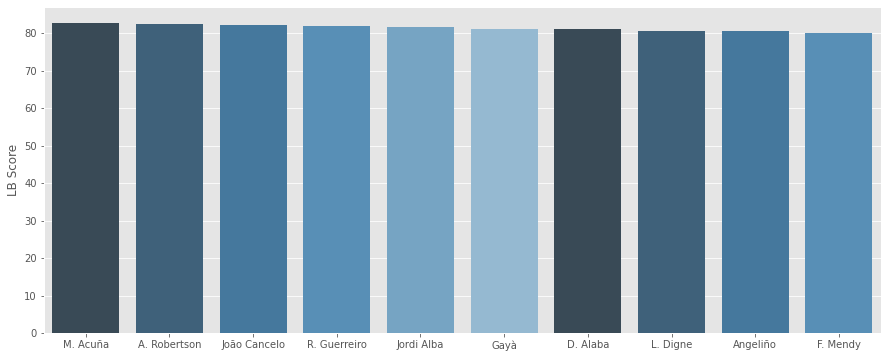

```python
#DEFENSOR LATERAL ESQUERRA:
plt.figure(figsize= (15,6))
sd = wing_back_left.sort_values('best_wb',ascending=False)[:10]
x2 = np.array(list(sd['short_name']))
y2 = np.array(list(sd['best_wb']))
sns.barplot(x2, y2, palette=sns.color_palette("Blues_d"))
plt.ylabel("LB Score")
```

```python
sd = sd.sort_values(['defending','skill_ball_control','attacking_crossing'],ascending=(False,False,False)).head(10)
sd
```

|  | sofifa_id | player_url | short_name | long_name | player_positions | overall | potential | value_eur | wage_eur | age | ... | rcb | rb | gk | player_face_url | club_logo_url | club_flag_url | nation_logo_url | nation_flag_url | best_center_backs | best_wb |
| --- | --- | --- | --- | --- | --- | --- | --- | --- | --- | --- | --- | --- | --- | --- | --- | --- | --- | --- | --- | --- | --- |
| 107 | 197445 | https://sofifa.com/player/197445/david-alaba/2... | D. Alaba | David Olatukunbo Alaba | CB, LB | 84 | 84 | 35500000.0 | 195000.0 | 29 | ... | 82+2 | 82+2 | 18+3 | https://cdn.sofifa.net/players/197/445/22_120.png | https://cdn.sofifa.net/teams/243/60.png | https://cdn.sofifa.net/flags/es.png | https://cdn.sofifa.net/teams/1322/60.png | https://cdn.sofifa.net/flags/at.png | 80.688525 | 80.98 |
| 42 | 216267 | https://sofifa.com/player/216267/andrew-robert... | A. Robertson | Andrew Robertson | LB | 87 | 88 | 83500000.0 | 175000.0 | 27 | ... | 79+3 | 84+3 | 18+3 | https://cdn.sofifa.net/players/216/267/22_120.png | https://cdn.sofifa.net/teams/9/60.png | https://cdn.sofifa.net/flags/gb-eng.png | https://cdn.sofifa.net/teams/1359/60.png | https://cdn.sofifa.net/flags/gb-sct.png | 81.163934 | 82.44 |
| 62 | 210514 | https://sofifa.com/player/210514/joao-pedro-ca... | João Cancelo | João Pedro Cavaco Cancelo | RB, LB | 86 | 87 | 71500000.0 | 185000.0 | 27 | ... | 78+3 | 83+3 | 19+3 | https://cdn.sofifa.net/players/210/514/22_120.png | https://cdn.sofifa.net/teams/10/60.png | https://cdn.sofifa.net/flags/gb-eng.png | https://cdn.sofifa.net/teams/1354/60.png | https://cdn.sofifa.net/flags/pt.png | 80.606557 | 82.18 |
| 111 | 200458 | https://sofifa.com/player/200458/lucas-digne/2... | L. Digne | Lucas Digne | LB | 84 | 84 | 40500000.0 | 110000.0 | 27 | ... | 79+2 | 82+2 | 17+2 | https://cdn.sofifa.net/players/200/458/22_120.png | https://cdn.sofifa.net/teams/7/60.png | https://cdn.sofifa.net/flags/gb-eng.png | https://cdn.sofifa.net/teams/1335/60.png | https://cdn.sofifa.net/flags/fr.png | 81.967213 | 80.66 |
| 134 | 224334 | https://sofifa.com/player/224334/marcos-acuna/... | M. Acuña | Marcos Javier Acuña | LB, LM | 84 | 84 | 37000000.0 | 45000.0 | 29 | ... | 79+2 | 82+2 | 20+2 | https://cdn.sofifa.net/players/224/334/22_120.png | https://cdn.sofifa.net/teams/481/60.png | https://cdn.sofifa.net/flags/es.png | https://cdn.sofifa.net/teams/1369/60.png | https://cdn.sofifa.net/flags/ar.png | 80.327869 | 82.80 |
| 174 | 211688 | https://sofifa.com/player/211688/jose-luis-gay... | Gayà | José Luís Gayà Peña | LB, LWB, LM | 83 | 86 | 43500000.0 | 48000.0 | 26 | ... | 76+3 | 81+3 | 19+3 | https://cdn.sofifa.net/players/211/688/22_120.png | https://cdn.sofifa.net/teams/461/60.png | https://cdn.sofifa.net/flags/es.png | https://cdn.sofifa.net/teams/1362/60.png | https://cdn.sofifa.net/flags/es.png | 77.278689 | 81.12 |
| 187 | 228618 | https://sofifa.com/player/228618/ferland-mendy... | F. Mendy | Ferland Mendy | LB | 83 | 86 | 43500000.0 | 170000.0 | 26 | ... | 79+2 | 81+2 | 18+2 | https://cdn.sofifa.net/players/228/618/22_120.png | https://cdn.sofifa.net/teams/243/60.png | https://cdn.sofifa.net/flags/es.png | NaN | https://cdn.sofifa.net/flags/fr.png | 80.459016 | 80.14 |
| 50 | 189332 | https://sofifa.com/player/189332/jordi-alba-ra... | Jordi Alba | Jordi Alba Ramos | LB, LM | 86 | 86 | 47000000.0 | 200000.0 | 32 | ... | 76+3 | 82+3 | 19+3 | https://cdn.sofifa.net/players/189/332/22_120.png | https://cdn.sofifa.net/teams/241/60.png | https://cdn.sofifa.net/flags/es.png | https://cdn.sofifa.net/teams/1362/60.png | https://cdn.sofifa.net/flags/es.png | 79.524590 | 81.74 |
| 124 | 209889 | https://sofifa.com/player/209889/raphael-guerr... | R. Guerreiro | Raphaël Adelino José Guerreiro | LB, LM | 84 | 84 | 40500000.0 | 79000.0 | 27 | ... | 71+3 | 80+3 | 18+3 | https://cdn.sofifa.net/players/209/889/22_120.png | https://cdn.sofifa.net/teams/22/60.png | https://cdn.sofifa.net/flags/de.png | https://cdn.sofifa.net/teams/1354/60.png | https://cdn.sofifa.net/flags/pt.png | 75.360656 | 81.90 |
| 180 | 220651 | https://sofifa.com/player/220651/jose-angel-es... | Angeliño | José Ángel Esmoris Tasende | LWB, LM | 83 | 86 | 46000000.0 | 77000.0 | 24 | ... | 75+2 | 80+2 | 19+2 | https://cdn.sofifa.net/players/220/651/22_120.png | https://cdn.sofifa.net/teams/112172/60.png | https://cdn.sofifa.net/flags/de.png | NaN | https://cdn.sofifa.net/flags/es.png | 78.262295 | 80.52 |

10 rows × 112 columns

**M.Acuña** és el millor defensa esquerra segons el nostre rànquing.**A.Robertson** i **J.Cancelo** també són bones opcions. A més, tots dos estan en les primeres posicions segons capacitats en defensa, control de la pilota i atac. Cancelo pot ser un bon reserva, ja que té capacitats per jugar tant com a lateral dret com a esquerre.

El millors defenses centrals són **Marquinhos** i **Sergio Ramos**. **E.Can** i **V. vanDijk** serien bones opcions de reserves. Aquest últim, a més, està el primer en capacitats en defensa, control de la pilota i atac.

Per tant, la nostra linia defensiva ideal estaria formada per:

- Com a lateral dret **J.Kimmich**, que, a més, té les millors capacitats en defensa, control de la pilota i atac. Reserves: **J.Cancelo** o **T.Alexander-Arnold**.
- Defenses lateral esquerra **M.Acuña**. Reserves: **A.Robertson** i **J.Cancelo**. Tots dos reserves estan en les primeres posicions segons capacitats en defensa, control de la pilota i atac.
- Defensors centrals: **Marquinhos** i **Sergio Ramos**. Reserves: **E.Can** i **V. vanDijk** . Aquest últim està el primer en capacitats en defensa, control de la pilota i atac.

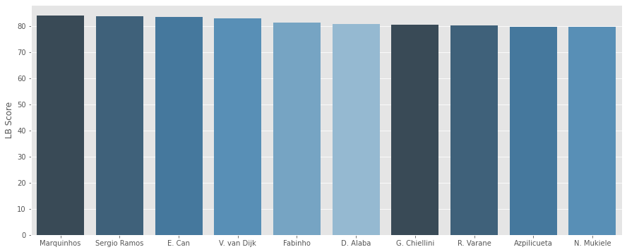

```python
#DEFENSOR CENTRAL:
plt.figure(figsize= (15,6))
sd = center_back.sort_values('best_center_backs',ascending=False)[:10]
x2 = np.array(list(sd['short_name']))
y2 = np.array(list(sd['best_center_backs']))
sns.barplot(x2, y2, palette=sns.color_palette("Blues_d"))
plt.ylabel("LB Score")
```

```python
sd = sd.sort_values(['defending','skill_ball_control','attacking_crossing'],ascending=(False,False,False)).head(10)
sd
```

|  | sofifa_id | player_url | short_name | long_name | player_positions | overall | potential | value_eur | wage_eur | age | ... | rcb | rb | gk | player_face_url | club_logo_url | club_flag_url | nation_logo_url | nation_flag_url | best_center_backs | best_wb |
| --- | --- | --- | --- | --- | --- | --- | --- | --- | --- | --- | --- | --- | --- | --- | --- | --- | --- | --- | --- | --- | --- |
| 15 | 203376 | https://sofifa.com/player/203376/virgil-van-di... | V. van Dijk | Virgil van Dijk | CB | 89 | 89 | 86000000.0 | 230000.0 | 29 | ... | 88+1 | 81+3 | 20+3 | https://cdn.sofifa.net/players/203/376/22_120.png | https://cdn.sofifa.net/teams/9/60.png | https://cdn.sofifa.net/flags/gb-eng.png | https://cdn.sofifa.net/teams/105035/60.png | https://cdn.sofifa.net/flags/nl.png | 82.918033 | 78.14 |
| 39 | 207865 | https://sofifa.com/player/207865/marcos-aoas-c... | Marquinhos | Marcos Aoás Corrêa | CB, CDM | 87 | 90 | 90500000.0 | 135000.0 | 27 | ... | 86+3 | 84+3 | 18+3 | https://cdn.sofifa.net/players/207/865/22_120.png | https://cdn.sofifa.net/teams/73/60.png | https://cdn.sofifa.net/flags/fr.png | NaN | https://cdn.sofifa.net/flags/br.png | 83.983607 | 81.80 |
| 47 | 138956 | https://sofifa.com/player/138956/giorgio-chiel... | G. Chiellini | Giorgio Chiellini | CB | 86 | 86 | 12000000.0 | 88000.0 | 36 | ... | 85+1 | 78+3 | 12+3 | https://cdn.sofifa.net/players/138/956/22_120.png | https://cdn.sofifa.net/teams/45/60.png | https://cdn.sofifa.net/flags/it.png | https://cdn.sofifa.net/teams/1343/60.png | https://cdn.sofifa.net/flags/it.png | 80.573770 | 73.10 |
| 22 | 155862 | https://sofifa.com/player/155862/sergio-ramos-... | Sergio Ramos | Sergio Ramos García | CB | 88 | 88 | 24000000.0 | 115000.0 | 35 | ... | 87+1 | 83+3 | 18+3 | https://cdn.sofifa.net/players/155/862/22_120.png | https://cdn.sofifa.net/teams/73/60.png | https://cdn.sofifa.net/flags/fr.png | https://cdn.sofifa.net/teams/1362/60.png | https://cdn.sofifa.net/flags/es.png | 83.786885 | 83.12 |
| 57 | 201535 | https://sofifa.com/player/201535/raphael-varan... | R. Varane | Raphaël Varane | CB | 86 | 88 | 68500000.0 | 180000.0 | 28 | ... | 85+3 | 80+3 | 18+3 | https://cdn.sofifa.net/players/201/535/22_120.png | https://cdn.sofifa.net/teams/11/60.png | https://cdn.sofifa.net/flags/gb-eng.png | https://cdn.sofifa.net/teams/1335/60.png | https://cdn.sofifa.net/flags/fr.png | 80.131148 | 75.76 |
| 61 | 209499 | https://sofifa.com/player/209499/fabio-henriqu... | Fabinho | Fábio Henrique Tavares | CDM, CB | 86 | 88 | 73500000.0 | 165000.0 | 27 | ... | 84+3 | 82+3 | 18+3 | https://cdn.sofifa.net/players/209/499/22_120.png | https://cdn.sofifa.net/teams/9/60.png | https://cdn.sofifa.net/flags/gb-eng.png | NaN | https://cdn.sofifa.net/flags/br.png | 81.393443 | 80.98 |
| 235 | 208333 | https://sofifa.com/player/208333/emre-can/220002 | E. Can | Emre Can | CM, CB, CDM | 82 | 83 | 35000000.0 | 72000.0 | 27 | ... | 84-1 | 82+1 | 19+3 | https://cdn.sofifa.net/players/208/333/22_120.png | https://cdn.sofifa.net/teams/22/60.png | https://cdn.sofifa.net/flags/de.png | NaN | https://cdn.sofifa.net/flags/de.png | 83.360656 | 81.14 |
| 148 | 184432 | https://sofifa.com/player/184432/cesar-azpilic... | Azpilicueta | César Azpilicueta Tanco | CB, RWB | 83 | 83 | 25000000.0 | 125000.0 | 31 | ... | 82+1 | 80+3 | 17+3 | https://cdn.sofifa.net/players/184/432/22_120.png | https://cdn.sofifa.net/teams/5/60.png | https://cdn.sofifa.net/flags/gb-eng.png | https://cdn.sofifa.net/teams/1362/60.png | https://cdn.sofifa.net/flags/es.png | 79.786885 | 79.22 |
| 107 | 197445 | https://sofifa.com/player/197445/david-alaba/2... | D. Alaba | David Olatukunbo Alaba | CB, LB | 84 | 84 | 35500000.0 | 195000.0 | 29 | ... | 82+2 | 82+2 | 18+3 | https://cdn.sofifa.net/players/197/445/22_120.png | https://cdn.sofifa.net/teams/243/60.png | https://cdn.sofifa.net/flags/es.png | https://cdn.sofifa.net/teams/1322/60.png | https://cdn.sofifa.net/flags/at.png | 80.688525 | 80.98 |
| 361 | 226166 | https://sofifa.com/player/226166/nordi-mukiele... | N. Mukiele | Nordi Mukiele Mulere | RWB, CB, RM | 81 | 85 | 34500000.0 | 65000.0 | 23 | ... | 81+2 | 79+2 | 18+2 | https://cdn.sofifa.net/players/226/166/22_120.png | https://cdn.sofifa.net/teams/112172/60.png | https://cdn.sofifa.net/flags/de.png | NaN | https://cdn.sofifa.net/flags/fr.png | 79.770492 | 75.98 |

10 rows × 112 columns

```python
import pandas as pd
import matplotlib as plt
import seaborn as sns
import matplotlib.pyplot as plt
import numpy as np
%matplotlib inline


#FEMENÍ
df = pd.read_csv('data/female_players_22.csv', low_memory = False)

#weights
a = 0.5
b = 1
c= 2
d = 3

df['best_center_backs'] = (d*df.defending + c*df.mentality_interceptions +
                           d*df.defending_sliding_tackle + d*df.defending_standing_tackle +
                           b*df.mentality_vision + b*df.mentality_composure +
                           b*df.skill_curve + a*df.skill_ball_control+
                           b*df.skill_long_passing + c*df.movement_acceleration +
                           b*df.movement_sprint_speed + d*df.power_stamina +
                           d*df.power_jumping + b*df.power_long_shots +
                           d*df.defending_marking_awareness +
                           c*df.mentality_aggression)/(a + 6*b + 3*c + 6*d)

df['best_wb'] = (d*df.defending + b*df.skill_ball_control + a*df.dribbling +
                 a*df.defending_marking_awareness + d*df.defending_standing_tackle +
                 d*df.defending_sliding_tackle + a*df.mentality_positioning +
                 c*df.attacking_crossing + b*df.attacking_short_passing +
                 c*df.skill_long_passing + d*df.movement_reactions + d*df.movement_agility +
                 c*df.power_stamina + a*df.attacking_finishing)/(4*a + 2*b + 3*c + 5*d)

# Best Right Wing Back Talents (RB, RWB)

wing_back_right = df[df.player_positions.str.contains('\\b(?:RB)|(?:RWB)\\b', regex=True)]

# Best Left Wing Back Talents (LB, LWB)

wing_back_left = df[df.player_positions.str.contains('\\b(?:LB)|(?:LWB)\\b', regex=True)]

# Best Centre Back Talents (CB)

center_back = df[df.player_positions.str.contains('CB')]
```

## Millor defensa equip femení.

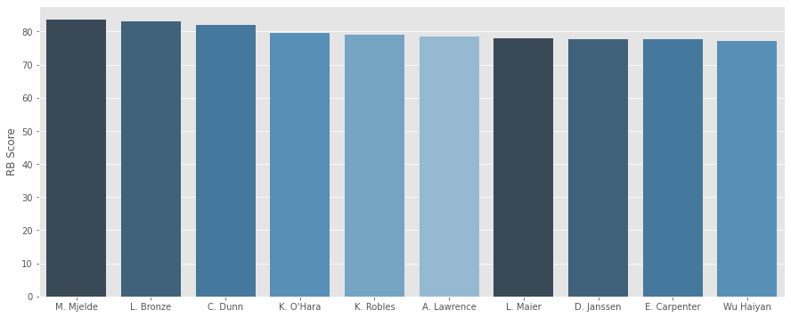

```python
#DEFENSORA LATERAL DRETA:
plt.figure(figsize= (15,6))
sd = wing_back_right.sort_values('best_wb',ascending=False)[:10]
x2 = np.array(list(sd['short_name']))
y2 = np.array(list(sd['best_wb']))
sns.barplot(x2, y2, palette=sns.color_palette("Blues_d"))
plt.ylabel("RB Score")
```

```python
sd = sd.sort_values(['defending','skill_ball_control','attacking_crossing'],ascending=(False,False,False)).head(10)
sd
```

|  | sofifa_id | player_url | short_name | long_name | player_positions | overall | potential | value_eur | wage_eur | age | ... | rcb | rb | gk | player_face_url | club_logo_url | club_flag_url | nation_logo_url | nation_flag_url | best_center_backs | best_wb |
| --- | --- | --- | --- | --- | --- | --- | --- | --- | --- | --- | --- | --- | --- | --- | --- | --- | --- | --- | --- | --- | --- |
| 0 | 227246 | https://sofifa.com/player/227246/lucy-bronze/2... | L. Bronze | Lucia Roberta Tough Bronze | RB, CM | 92 | 92 | NaN | NaN | 29 | ... | 87+3 | 88+3 | 21+3 | https://cdn.sofifa.com/players/227/246/22_120.png | NaN | NaN | https://cdn.sofifa.com/teams/113002/60.png | https://cdn.sofifa.com/flags/gb-eng.png | 83.393443 | 83.16 |
| 53 | 227282 | https://sofifa.com/player/227282/maren-mjelde/... | M. Mjelde | Maren Nævdal Mjelde | CB, RB | 83 | 83 | NaN | NaN | 31 | ... | 82+1 | 82+1 | 20+3 | https://cdn.sofifa.com/players/227/282/22_120.png | NaN | NaN | https://cdn.sofifa.com/teams/113007/60.png | https://cdn.sofifa.com/flags/no.png | 83.573770 | 83.58 |
| 24 | 226336 | https://sofifa.com/player/226336/crystal-dunn/... | C. Dunn | Crystal Alyssia Dunn Soubrier | LB, RB, LM | 86 | 86 | NaN | NaN | 28 | ... | 78+3 | 83+3 | 20+3 | https://cdn.sofifa.com/players/226/336/22_120.png | NaN | NaN | https://cdn.sofifa.com/teams/113009/60.png | https://cdn.sofifa.com/flags/us.png | 78.868852 | 82.04 |
| 29 | 226318 | https://sofifa.com/player/226318/kelley-ohara/... | K. O'Hara | Kelley Maureen O'Hara | RB, LB | 85 | 85 | NaN | NaN | 32 | ... | 79+3 | 81+3 | 19+3 | https://cdn.sofifa.com/players/226/318/22_120.png | NaN | NaN | https://cdn.sofifa.com/teams/113009/60.png | https://cdn.sofifa.com/flags/us.png | 75.475410 | 79.46 |
| 57 | 227466 | https://sofifa.com/player/227466/kenti-robles/... | K. Robles | Vaitiare Kenti Robles Salas | RB | 83 | 83 | NaN | NaN | 30 | ... | 79+3 | 81+2 | 19+3 | https://cdn.sofifa.com/players/227/466/22_120.png | NaN | NaN | https://cdn.sofifa.com/teams/113010/60.png | https://cdn.sofifa.com/flags/mx.png | 80.786885 | 78.98 |
| 73 | 227300 | https://sofifa.com/player/227300/leonie-maier/... | L. Maier | Leonie Rebekka Maier | RB, LB | 82 | 82 | NaN | NaN | 28 | ... | 78+2 | 80+2 | 21+2 | https://cdn.sofifa.com/players/227/300/22_120.png | NaN | NaN | https://cdn.sofifa.com/teams/113004/60.png | https://cdn.sofifa.com/flags/de.png | 77.377049 | 78.04 |
| 68 | 226922 | https://sofifa.com/player/226922/haiyan-wu/220002 | Wu Haiyan | 吴海燕 | CB, RB | 82 | 82 | NaN | NaN | 28 | ... | 81+1 | 79+2 | 19+2 | https://cdn.sofifa.com/players/226/922/22_120.png | NaN | NaN | https://cdn.sofifa.com/teams/113001/60.png | https://cdn.sofifa.com/flags/cn.png | 76.721311 | 77.28 |
| 130 | 233756 | https://sofifa.com/player/233756/dominique-jan... | D. Janssen | Dominique Johanna Anna Petrone Janssen | CB, RB, LB | 79 | 80 | NaN | NaN | 26 | ... | 79+1 | 79+1 | 23+3 | https://cdn.sofifa.com/players/233/756/22_120.png | NaN | NaN | https://cdn.sofifa.com/teams/113011/60.png | https://cdn.sofifa.com/flags/nl.png | 78.540984 | 77.78 |
| 75 | 227392 | https://sofifa.com/player/227392/ashley-lawren... | A. Lawrence | Ashley Elizabeth Marie Lawrence | RB, CM, LB | 82 | 85 | NaN | NaN | 26 | ... | 77+3 | 80+3 | 20+3 | https://cdn.sofifa.com/players/227/392/22_120.png | NaN | NaN | https://cdn.sofifa.com/teams/113000/60.png | https://cdn.sofifa.com/flags/ca.png | 78.672131 | 78.48 |
| 81 | 240030 | https://sofifa.com/player/240030/ellie-carpent... | E. Carpenter | Ellie Madison Carpenter | RB | 82 | 91 | NaN | NaN | 21 | ... | 77+2 | 80+2 | 21+2 | https://cdn.sofifa.com/players/240/030/22_120.png | NaN | NaN | https://cdn.sofifa.com/teams/112998/60.png | https://cdn.sofifa.com/flags/au.png | 76.622951 | 77.64 |

10 rows × 112 columns

La millor defensa **lateral dreta** és **M.Mjelde**, seguida de **L.Bronze** i **C.Dunn**, que es poden quedar com a reserves.. Les tres són les millors en capacitats en defensa, control de la pilota i atac.

La millor defensa **lateral esquerra** és **A.Majri**, seguida de **C.Dunn** i **M.Eriksson**, que es poden quedar com a reserves. Les tres també són les millors en capacitats en defensa, control de la pilota i atac.

Les millors defensores **centrals** són **M.Mjelde**, **W.Renard** i **J.Ertz**. Com **W.Renard** i **J.Ertz**, tenen millors capacitats en defensa, control de la pilota i atac, ocuparan la titularitat de defenses centrals. **M.Mjelde** es quedarà com a titular de la defensa lateral dreta. Com a reserva, **K.Buchanan** i **B. Sauerbrunn**, són bones opcions.

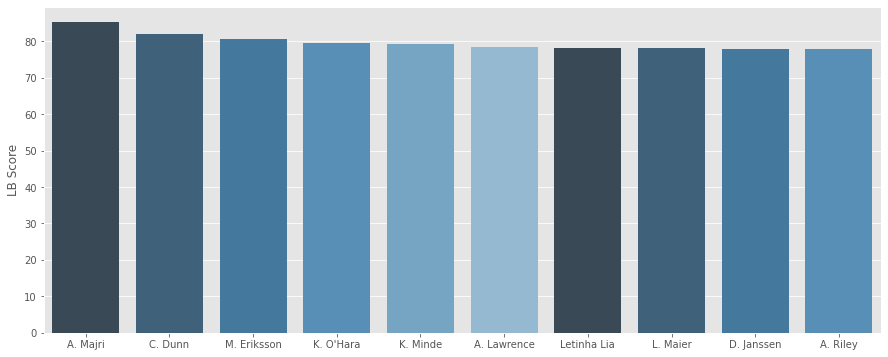

```python
#DEFENSORA LATERAL ESQUERRA:
plt.figure(figsize= (15,6))
sd = wing_back_left.sort_values('best_wb',ascending=False)[:10]
x2 = np.array(list(sd['short_name']))
y2 = np.array(list(sd['best_wb']))
sns.barplot(x2, y2, palette=sns.color_palette("Blues_d"))
plt.ylabel("LB Score")
```

```python
sd = sd.sort_values(['defending','skill_ball_control','attacking_crossing'],ascending=(False,False,False)).head(10)
sd
```

|  | sofifa_id | player_url | short_name | long_name | player_positions | overall | potential | value_eur | wage_eur | age | ... | rcb | rb | gk | player_face_url | club_logo_url | club_flag_url | nation_logo_url | nation_flag_url | best_center_backs | best_wb |
| --- | --- | --- | --- | --- | --- | --- | --- | --- | --- | --- | --- | --- | --- | --- | --- | --- | --- | --- | --- | --- | --- |
| 19 | 227350 | https://sofifa.com/player/227350/amel-majri/22... | A. Majri | Amel Majri | LM, LB | 87 | 87 | NaN | NaN | 28 | ... | 83+3 | 86+1 | 20+3 | https://cdn.sofifa.com/players/227/350/22_120.png | NaN | NaN | https://cdn.sofifa.com/teams/113003/60.png | https://cdn.sofifa.com/flags/fr.png | 82.672131 | 85.20 |
| 31 | 226998 | https://sofifa.com/player/226998/magdalena-eri... | M. Eriksson | Magdalena Lilly Eriksson | LB, CB | 85 | 85 | NaN | NaN | 27 | ... | 82+3 | 82+3 | 19+3 | https://cdn.sofifa.com/players/226/998/22_120.png | NaN | NaN | https://cdn.sofifa.com/teams/113008/60.png | https://cdn.sofifa.com/flags/se.png | 78.803279 | 80.66 |
| 24 | 226336 | https://sofifa.com/player/226336/crystal-dunn/... | C. Dunn | Crystal Alyssia Dunn Soubrier | LB, RB, LM | 86 | 86 | NaN | NaN | 28 | ... | 78+3 | 83+3 | 20+3 | https://cdn.sofifa.com/players/226/336/22_120.png | NaN | NaN | https://cdn.sofifa.com/teams/113009/60.png | https://cdn.sofifa.com/flags/us.png | 78.868852 | 82.04 |
| 29 | 226318 | https://sofifa.com/player/226318/kelley-ohara/... | K. O'Hara | Kelley Maureen O'Hara | RB, LB | 85 | 85 | NaN | NaN | 32 | ... | 79+3 | 81+3 | 19+3 | https://cdn.sofifa.com/players/226/318/22_120.png | NaN | NaN | https://cdn.sofifa.com/teams/113009/60.png | https://cdn.sofifa.com/flags/us.png | 75.475410 | 79.46 |
| 73 | 227300 | https://sofifa.com/player/227300/leonie-maier/... | L. Maier | Leonie Rebekka Maier | RB, LB | 82 | 82 | NaN | NaN | 28 | ... | 78+2 | 80+2 | 21+2 | https://cdn.sofifa.com/players/227/300/22_120.png | NaN | NaN | https://cdn.sofifa.com/teams/113004/60.png | https://cdn.sofifa.com/flags/de.png | 77.377049 | 78.04 |
| 130 | 233756 | https://sofifa.com/player/233756/dominique-jan... | D. Janssen | Dominique Johanna Anna Petrone Janssen | CB, RB, LB | 79 | 80 | NaN | NaN | 26 | ... | 79+1 | 79+1 | 23+3 | https://cdn.sofifa.com/players/233/756/22_120.png | NaN | NaN | https://cdn.sofifa.com/teams/113011/60.png | https://cdn.sofifa.com/flags/nl.png | 78.540984 | 77.78 |
| 75 | 227392 | https://sofifa.com/player/227392/ashley-lawren... | A. Lawrence | Ashley Elizabeth Marie Lawrence | RB, CM, LB | 82 | 85 | NaN | NaN | 26 | ... | 77+3 | 80+3 | 20+3 | https://cdn.sofifa.com/players/227/392/22_120.png | NaN | NaN | https://cdn.sofifa.com/teams/113000/60.png | https://cdn.sofifa.com/flags/ca.png | 78.672131 | 78.48 |
| 72 | 227281 | https://sofifa.com/player/227281/kristine-mind... | K. Minde | Kristine Minde | LB, LM | 82 | 82 | NaN | NaN | 28 | ... | 76+2 | 80+2 | 19+2 | https://cdn.sofifa.com/players/227/281/22_120.png | NaN | NaN | https://cdn.sofifa.com/teams/113007/60.png | https://cdn.sofifa.com/flags/no.png | 78.786885 | 79.32 |
| 94 | 245177 | https://sofifa.com/player/245177/leticia-lia-m... | Letinha Lia | Letícia Lia Medeiros Resende | LB | 81 | 81 | NaN | NaN | 37 | ... | 75+2 | 79+2 | 20+2 | https://cdn.sofifa.com/players/245/177/22_120.png | NaN | NaN | https://cdn.sofifa.com/teams/112999/60.png | https://cdn.sofifa.com/flags/br.png | 76.409836 | 78.22 |
| 111 | 233343 | https://sofifa.com/player/233343/ali-riley/220002 | A. Riley | Alexandra Lowe Riley | LB, LM, LWB | 80 | 80 | NaN | NaN | 33 | ... | 75+3 | 78+2 | 19+3 | https://cdn.sofifa.com/players/233/343/22_120.png | NaN | NaN | https://cdn.sofifa.com/teams/113258/60.png | https://cdn.sofifa.com/flags/nz.png | 74.639344 | 77.72 |

10 rows × 112 columns

Les millors defensores centrals:

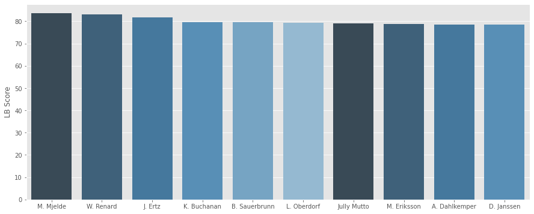

```python
#DEFENSORA CENTRAL:
plt.figure(figsize= (15,6))
sd = center_back.sort_values('best_center_backs',ascending=False)[:10]
x2 = np.array(list(sd['short_name']))
y2 = np.array(list(sd['best_center_backs']))
sns.barplot(x2, y2, palette=sns.color_palette("Blues_d"))
plt.ylabel("LB Score")
```

```python
sd = sd.sort_values(['defending','skill_ball_control','attacking_crossing'],ascending=(False,False,False)).head(10)
sd
```

|  | sofifa_id | player_url | short_name | long_name | player_positions | overall | potential | value_eur | wage_eur | age | ... | rcb | rb | gk | player_face_url | club_logo_url | club_flag_url | nation_logo_url | nation_flag_url | best_center_backs | best_wb |
| --- | --- | --- | --- | --- | --- | --- | --- | --- | --- | --- | --- | --- | --- | --- | --- | --- | --- | --- | --- | --- | --- |
| 1 | 227316 | https://sofifa.com/player/227316/wendie-renard... | W. Renard | Wéndèleine Thérèse Renard | CB | 92 | 92 | NaN | NaN | 30 | ... | 90+2 | 80+3 | 20+3 | https://cdn.sofifa.com/players/227/316/22_120.png | NaN | NaN | https://cdn.sofifa.com/teams/113003/60.png | https://cdn.sofifa.com/flags/fr.png | 83.032787 | 76.98 |
| 14 | 226177 | https://sofifa.com/player/226177/becky-sauerbr... | B. Sauerbrunn | Rebecca Elizabeth Sauerbrunn | CB, RB | 88 | 88 | NaN | NaN | 36 | ... | 86+2 | 81+3 | 20+3 | https://cdn.sofifa.com/players/226/177/22_120.png | NaN | NaN | https://cdn.sofifa.com/teams/113009/60.png | https://cdn.sofifa.com/flags/us.png | 79.672131 | 75.20 |
| 10 | 226333 | https://sofifa.com/player/226333/julie-ertz/22... | J. Ertz | Julie Beth Ertz | CDM, CB | 89 | 89 | NaN | NaN | 29 | ... | 86+3 | 84+3 | 20+3 | https://cdn.sofifa.com/players/226/333/22_120.png | NaN | NaN | https://cdn.sofifa.com/teams/113009/60.png | https://cdn.sofifa.com/flags/us.png | 81.836066 | 81.58 |
| 53 | 227282 | https://sofifa.com/player/227282/maren-mjelde/... | M. Mjelde | Maren Nævdal Mjelde | CB, RB | 83 | 83 | NaN | NaN | 31 | ... | 82+1 | 82+1 | 20+3 | https://cdn.sofifa.com/players/227/282/22_120.png | NaN | NaN | https://cdn.sofifa.com/teams/113007/60.png | https://cdn.sofifa.com/flags/no.png | 83.573770 | 83.58 |
| 47 | 248717 | https://sofifa.com/player/248717/lena-oberdorf... | L. Oberdorf | Lena Sophie Oberdorf | CB, CDM | 84 | 92 | NaN | NaN | 19 | ... | 83+2 | 80+2 | 20+2 | https://cdn.sofifa.com/players/248/717/22_120.png | NaN | NaN | https://cdn.sofifa.com/teams/113004/60.png | https://cdn.sofifa.com/flags/de.png | 79.311475 | 79.48 |
| 40 | 227383 | https://sofifa.com/player/227383/kadeisha-buch... | K. Buchanan | Kadeisha Buchanan | CB | 84 | 87 | NaN | NaN | 25 | ... | 84+3 | 77+3 | 22+3 | https://cdn.sofifa.com/players/227/383/22_120.png | NaN | NaN | https://cdn.sofifa.com/teams/113000/60.png | https://cdn.sofifa.com/flags/ca.png | 79.704918 | 74.34 |
| 31 | 226998 | https://sofifa.com/player/226998/magdalena-eri... | M. Eriksson | Magdalena Lilly Eriksson | LB, CB | 85 | 85 | NaN | NaN | 27 | ... | 82+3 | 82+3 | 19+3 | https://cdn.sofifa.com/players/226/998/22_120.png | NaN | NaN | https://cdn.sofifa.com/teams/113008/60.png | https://cdn.sofifa.com/flags/se.png | 78.803279 | 80.66 |
| 78 | 236641 | https://sofifa.com/player/236641/abby-dahlkemp... | A. Dahlkemper | Abigail Lynn Dahlkemper | CB | 82 | 83 | NaN | NaN | 28 | ... | 82+1 | 80+3 | 20+3 | https://cdn.sofifa.com/players/236/641/22_120.png | NaN | NaN | https://cdn.sofifa.com/teams/113009/60.png | https://cdn.sofifa.com/flags/us.png | 78.590164 | 77.32 |
| 83 | 245188 | https://sofifa.com/player/245188/julia-maria-m... | Jully Mutto | Júlia Maria Mutto Sampaio | CB | 82 | 82 | NaN | NaN | 33 | ... | 82 | 75+2 | 16+2 | https://cdn.sofifa.com/players/245/188/22_120.png | NaN | NaN | https://cdn.sofifa.com/teams/112999/60.png | https://cdn.sofifa.com/flags/br.png | 79.081967 | 71.72 |
| 130 | 233756 | https://sofifa.com/player/233756/dominique-jan... | D. Janssen | Dominique Johanna Anna Petrone Janssen | CB, RB, LB | 79 | 80 | NaN | NaN | 26 | ... | 79+1 | 79+1 | 23+3 | https://cdn.sofifa.com/players/233/756/22_120.png | NaN | NaN | https://cdn.sofifa.com/teams/113011/60.png | https://cdn.sofifa.com/flags/nl.png | 78.540984 | 77.78 |

10 rows × 112 columns

## Equip de veterans.

Format per homes i dones amb 30 o més anys.

```python
def read_add_year_gender(filepath: str, gender: str, year: int) -> pd.DataFrame:
    """Function with 3 inputs: filepath(+/or\), gender ['M' for Male
    or 'F' for Female], and year [from 2016 to 2022] of the data.
    Reads the file in filepath and returns a pandas dataframe with
    two new columns:
    - gender: 'Male' or 'Female'
    - year of the data"""
    year_n = [int(a) for a in str(year)]
    if gender == 'M':
        df = pd.read_csv(filepath + "players_" + str(year_n[2]) +
                         str(year_n[3]) + ".csv", low_memory = False)
        n = len(df.index)
        df['gender'] = ['Male']*n
        df['year'] = year
        return df

    elif gender == 'F':
        df = pd.read_csv(filepath + "female_players_" + str(year_n[2]) +
                         str(year_n[3]) + ".csv", low_memory = False)
        n = len(df.index)
        df['gender'] = ['Female']*n
        df['year'] = year
        return df
```

```python
def join_male_female(filepath: str, year: int) -> pd.DataFrame:
    """Function with 2 inputs: filepath  and year [from 2016 to 2022]
    of the data.
    Reads the file in filepath and returns a pandas dataframe with
    two new columns:
    - gender: 'Male' or 'Female'
    - year of the data"""
    df1 = read_add_year_gender(filepath, 'M', year)
    df2 = read_add_year_gender(filepath, 'F', year)
    joined_result = df1.append(df2)
    return joined_result


data6 = join_male_female('data/', 2022)
players = data6[data6['age']>29]
```

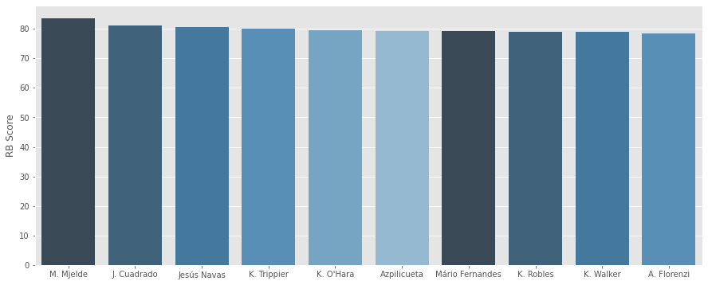

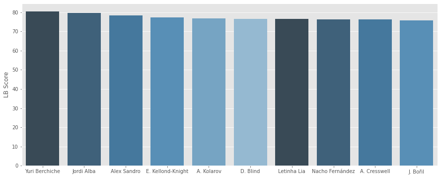

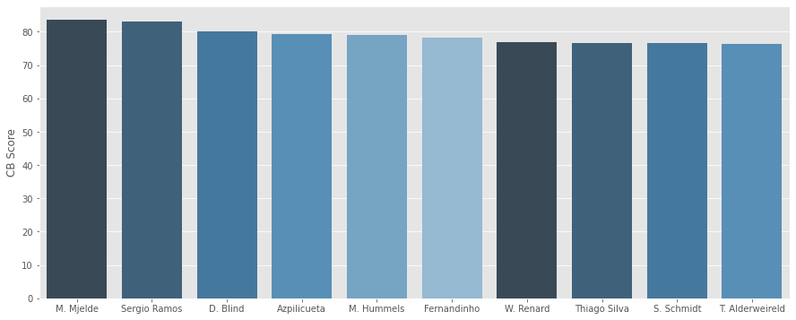

```python
players['player_positions'].str.split().apply(lambda x: x[0]).unique()

#weights
a = 0.5
b = 1
c= 2
d = 3

players['best_center_backs'] = (d*players.defending + c*players.mentality_interceptions +
                           d*players.defending_sliding_tackle + d*players.defending_standing_tackle +
                           b*players.mentality_vision + b*players.mentality_composure +
                           b*players.skill_curve + a*players.skill_ball_control+
                           b*players.skill_long_passing + c*players.movement_acceleration +
                           b*players.movement_sprint_speed + d*players.power_stamina +
                           d*players.power_jumping + b*players.power_long_shots +
                           d*players.defending_marking_awareness +
                           c*players.mentality_aggression)/(a + 6*b + 3*c + 6*d)

players['best_wb'] = (d*players.defending + b*players.skill_ball_control + a*players.dribbling +
                 a*players.defending_marking_awareness + d*players.defending_standing_tackle +
                 d*players.defending_sliding_tackle + a*players.mentality_positioning +
                 c*players.attacking_crossing + b*players.attacking_short_passing +
                 c*players.skill_long_passing + d*players.movement_reactions + d*players.movement_agility +
                 c*players.power_stamina + a*players.attacking_finishing)/(4*a + 2*b + 3*c + 5*d)

# Best Right Wing Back Talents (RB, RWB)

wing_back_right = players[players.player_positions.str.contains('\\b(?:RB)|(?:RWB)\\b', regex=True)]

# Best Left Wing Back Talents (LB, LWB)

wing_back_left = players[players.player_positions.str.contains('\\b(?:LB)|(?:LWB)\\b', regex=True)]

# Best Centre Back Talents (CB)

center_back = players[players.player_positions.str.contains('CB')]

#DEFENSOR LATERAL DRET:
plt.figure(figsize= (15,6))
sd = wing_back_right.sort_values('best_wb',ascending=False)[:10]
x2 = np.array(list(sd['short_name']))
y2 = np.array(list(sd['best_wb']))
sns.barplot(x2, y2, palette=sns.color_palette("Blues_d"))
plt.ylabel("RB Score")


#DEFENSOR LATERAL ESQUERRA:
plt.figure(figsize= (15,6))
sd3 = wing_back_left.sort_values('best_center_backs',ascending=False)[:10]
x2 = np.array(list(sd3['short_name']))
y2 = np.array(list(sd3['best_center_backs']))
sns.barplot(x2, y2, palette=sns.color_palette("Blues_d"))
plt.ylabel("LB Score")


#DEFENSOR CENTRAL:
plt.figure(figsize= (15,6))
sd2 = center_back.sort_values('best_wb',ascending=False)[:10]
x2 = np.array(list(sd2['short_name']))
y2 = np.array(list(sd2['best_wb']))
sns.barplot(x2, y2, palette=sns.color_palette("Blues_d"))
plt.ylabel("CB Score")
```

L'equip de Veterans podria tenir la següent linia defensiva:

- Defensa lateral dreta: **M.Mjelde** . Reserva: **J.Cuadrado**
- Defensa lateral esquerra: **Yuri Berchiche**. Reserva: **Jordi Alba**
- Defensa central:**Sergio Ramos** i **D.Blind**. A **M.Mjelde** la deixem com a lateral dreta, ja que és on té més puntuació en defensa, control de pilota i atac.

### Defensa lateral dreta: millors en capacitats en defensa, control de la pilota i atac.

```python
sd = sd.sort_values(['defending','skill_ball_control','attacking_crossing'],ascending=(False,False,False)).head(10)
sd
```

|  | sofifa_id | player_url | short_name | long_name | player_positions | overall | potential | value_eur | wage_eur | age | ... | gk | player_face_url | club_logo_url | club_flag_url | nation_logo_url | nation_flag_url | gender | year | best_center_backs | best_wb |
| --- | --- | --- | --- | --- | --- | --- | --- | --- | --- | --- | --- | --- | --- | --- | --- | --- | --- | --- | --- | --- | --- |
| 53 | 227282 | https://sofifa.com/player/227282/maren-mjelde/... | M. Mjelde | Maren Nævdal Mjelde | CB, RB | 83 | 83 | NaN | NaN | 31 | ... | 20+3 | https://cdn.sofifa.com/players/227/282/22_120.png | NaN | NaN | https://cdn.sofifa.com/teams/113007/60.png | https://cdn.sofifa.com/flags/no.png | Female | 2022 | 83.573770 | 83.58 |
| 148 | 184432 | https://sofifa.com/player/184432/cesar-azpilic... | Azpilicueta | César Azpilicueta Tanco | CB, RWB | 83 | 83 | 25000000.0 | 125000.0 | 31 | ... | 17+3 | https://cdn.sofifa.net/players/184/432/22_120.png | https://cdn.sofifa.net/teams/5/60.png | https://cdn.sofifa.net/flags/gb-eng.png | https://cdn.sofifa.net/teams/1362/60.png | https://cdn.sofifa.net/flags/es.png | Male | 2022 | 79.786885 | 79.22 |
| 29 | 226318 | https://sofifa.com/player/226318/kelley-ohara/... | K. O'Hara | Kelley Maureen O'Hara | RB, LB | 85 | 85 | NaN | NaN | 32 | ... | 19+3 | https://cdn.sofifa.com/players/226/318/22_120.png | NaN | NaN | https://cdn.sofifa.com/teams/113009/60.png | https://cdn.sofifa.com/flags/us.png | Female | 2022 | 75.475410 | 79.46 |
| 57 | 227466 | https://sofifa.com/player/227466/kenti-robles/... | K. Robles | Vaitiare Kenti Robles Salas | RB | 83 | 83 | NaN | NaN | 30 | ... | 19+3 | https://cdn.sofifa.com/players/227/466/22_120.png | NaN | NaN | https://cdn.sofifa.com/teams/113010/60.png | https://cdn.sofifa.com/flags/mx.png | Female | 2022 | 80.786885 | 78.98 |
| 104 | 186345 | https://sofifa.com/player/186345/kieran-trippi... | K. Trippier | Kieran Trippier | RB, RWB, RM | 84 | 84 | 36500000.0 | 74000.0 | 30 | ... | 19+2 | https://cdn.sofifa.net/players/186/345/22_120.png | https://cdn.sofifa.net/teams/240/60.png | https://cdn.sofifa.net/flags/es.png | https://cdn.sofifa.net/teams/1318/60.png | https://cdn.sofifa.net/flags/gb-eng.png | Male | 2022 | 79.213115 | 79.88 |
| 80 | 188377 | https://sofifa.com/player/188377/kyle-walker/2... | K. Walker | Kyle Walker | RB | 85 | 85 | 39000000.0 | 170000.0 | 31 | ... | 19+3 | https://cdn.sofifa.net/players/188/377/22_120.png | https://cdn.sofifa.net/teams/10/60.png | https://cdn.sofifa.net/flags/gb-eng.png | https://cdn.sofifa.net/teams/1318/60.png | https://cdn.sofifa.net/flags/gb-eng.png | Male | 2022 | 81.491803 | 78.84 |
| 98 | 146536 | https://sofifa.com/player/146536/jesus-navas-g... | Jesús Navas | Jesús Navas González | RB, RM | 84 | 84 | 13000000.0 | 30000.0 | 35 | ... | 18+2 | https://cdn.sofifa.net/players/146/536/22_120.png | https://cdn.sofifa.net/teams/481/60.png | https://cdn.sofifa.net/flags/es.png | NaN | https://cdn.sofifa.net/flags/es.png | Male | 2022 | 78.606557 | 80.66 |
| 220 | 193525 | https://sofifa.com/player/193525/mario-figueir... | Mário Fernandes | Mário Figueira Fernandes | RB | 82 | 82 | 26500000.0 | 57000.0 | 30 | ... | 20+2 | https://cdn.sofifa.net/players/193/525/22_120.png | https://cdn.sofifa.net/teams/315/60.png | https://cdn.sofifa.net/flags/ru.png | NaN | https://cdn.sofifa.net/flags/ru.png | Male | 2022 | 79.098361 | 79.10 |
| 157 | 193082 | https://sofifa.com/player/193082/juan-cuadrado... | J. Cuadrado | Juan Guillermo Cuadrado Bello | RB, RM | 83 | 83 | 19000000.0 | 95000.0 | 33 | ... | 15+3 | https://cdn.sofifa.net/players/193/082/22_120.png | https://cdn.sofifa.net/teams/45/60.png | https://cdn.sofifa.net/flags/it.png | NaN | https://cdn.sofifa.net/flags/co.png | Male | 2022 | 78.901639 | 81.06 |
| 321 | 203551 | https://sofifa.com/player/203551/alessandro-fl... | A. Florenzi | Alessandro Florenzi | RB, RWB | 81 | 81 | 22000000.0 | 58000.0 | 30 | ... | 17+3 | https://cdn.sofifa.net/players/203/551/22_120.png | https://cdn.sofifa.net/teams/47/60.png | https://cdn.sofifa.net/flags/it.png | NaN | https://cdn.sofifa.net/flags/it.png | Male | 2022 | 76.311475 | 78.36 |

10 rows × 114 columns

### Defensa central: millors en capacitats en defensa, control de la pilota i atac.

```python
sd2 = sd2.sort_values(['defending','skill_ball_control','attacking_crossing'],ascending=(False,False,False)).head(10)
sd2
```

|  | sofifa_id | player_url | short_name | long_name | player_positions | overall | potential | value_eur | wage_eur | age | ... | gk | player_face_url | club_logo_url | club_flag_url | nation_logo_url | nation_flag_url | gender | year | best_center_backs | best_wb |
| --- | --- | --- | --- | --- | --- | --- | --- | --- | --- | --- | --- | --- | --- | --- | --- | --- | --- | --- | --- | --- | --- |
| 1 | 227316 | https://sofifa.com/player/227316/wendie-renard... | W. Renard | Wéndèleine Thérèse Renard | CB | 92 | 92 | NaN | NaN | 30 | ... | 20+3 | https://cdn.sofifa.com/players/227/316/22_120.png | NaN | NaN | https://cdn.sofifa.com/teams/113003/60.png | https://cdn.sofifa.com/flags/fr.png | Female | 2022 | 83.032787 | 76.98 |
| 49 | 178603 | https://sofifa.com/player/178603/mats-hummels/... | M. Hummels | Mats Hummels | CB | 86 | 86 | 44000000.0 | 95000.0 | 32 | ... | 17+3 | https://cdn.sofifa.net/players/178/603/22_120.png | https://cdn.sofifa.net/teams/22/60.png | https://cdn.sofifa.net/flags/de.png | NaN | https://cdn.sofifa.net/flags/de.png | Male | 2022 | 77.393443 | 79.02 |
| 22 | 155862 | https://sofifa.com/player/155862/sergio-ramos-... | Sergio Ramos | Sergio Ramos García | CB | 88 | 88 | 24000000.0 | 115000.0 | 35 | ... | 18+3 | https://cdn.sofifa.net/players/155/862/22_120.png | https://cdn.sofifa.net/teams/73/60.png | https://cdn.sofifa.net/flags/fr.png | https://cdn.sofifa.net/teams/1362/60.png | https://cdn.sofifa.net/flags/es.png | Male | 2022 | 83.786885 | 83.12 |
| 71 | 164240 | https://sofifa.com/player/164240/thiago-emilia... | Thiago Silva | Thiago Emiliano da Silva | CB | 85 | 85 | 9500000.0 | 105000.0 | 36 | ... | 18+3 | https://cdn.sofifa.net/players/164/240/22_120.png | https://cdn.sofifa.net/teams/5/60.png | https://cdn.sofifa.net/flags/gb-eng.png | NaN | https://cdn.sofifa.net/flags/br.png | Male | 2022 | 78.245902 | 76.76 |
| 147 | 184087 | https://sofifa.com/player/184087/toby-alderwei... | T. Alderweireld | Toby Alderweireld | CB | 83 | 83 | NaN | NaN | 32 | ... | 21+3 | https://cdn.sofifa.net/players/184/087/22_120.png | NaN | NaN | https://cdn.sofifa.net/teams/1325/60.png | https://cdn.sofifa.net/flags/be.png | Male | 2022 | 78.311475 | 76.30 |
| 53 | 227282 | https://sofifa.com/player/227282/maren-mjelde/... | M. Mjelde | Maren Nævdal Mjelde | CB, RB | 83 | 83 | NaN | NaN | 31 | ... | 20+3 | https://cdn.sofifa.com/players/227/282/22_120.png | NaN | NaN | https://cdn.sofifa.com/teams/113007/60.png | https://cdn.sofifa.com/flags/no.png | Female | 2022 | 83.573770 | 83.58 |
| 140 | 135507 | https://sofifa.com/player/135507/fernando-luiz... | Fernandinho | Fernando Luiz Rosa | CDM, CB | 83 | 83 | 7000000.0 | 100000.0 | 36 | ... | 19+3 | https://cdn.sofifa.net/players/135/507/22_120.png | https://cdn.sofifa.net/teams/10/60.png | https://cdn.sofifa.net/flags/gb-eng.png | NaN | https://cdn.sofifa.net/flags/br.png | Male | 2022 | 78.639344 | 78.26 |
| 148 | 184432 | https://sofifa.com/player/184432/cesar-azpilic... | Azpilicueta | César Azpilicueta Tanco | CB, RWB | 83 | 83 | 25000000.0 | 125000.0 | 31 | ... | 17+3 | https://cdn.sofifa.net/players/184/432/22_120.png | https://cdn.sofifa.net/teams/5/60.png | https://cdn.sofifa.net/flags/gb-eng.png | https://cdn.sofifa.net/teams/1362/60.png | https://cdn.sofifa.net/flags/es.png | Male | 2022 | 79.786885 | 79.22 |
| 214 | 190815 | https://sofifa.com/player/190815/daley-blind/2... | D. Blind | Daley Blind | CB, CDM, LB | 82 | 82 | 21000000.0 | 23000.0 | 31 | ... | 19+3 | https://cdn.sofifa.net/players/190/815/22_120.png | https://cdn.sofifa.net/teams/245/60.png | https://cdn.sofifa.net/flags/nl.png | https://cdn.sofifa.net/teams/105035/60.png | https://cdn.sofifa.net/flags/nl.png | Male | 2022 | 76.557377 | 80.00 |
| 56 | 227405 | https://sofifa.com/player/227405/sophie-schmid... | S. Schmidt | Sophie Diana Schmidt | CM, CDM, CB | 83 | 83 | NaN | NaN | 33 | ... | 19+3 | https://cdn.sofifa.com/players/227/405/22_120.png | NaN | NaN | https://cdn.sofifa.com/teams/113000/60.png | https://cdn.sofifa.com/flags/ca.png | Female | 2022 | 74.655738 | 76.60 |

10 rows × 114 columns

### Defensa lateral esquerra: millors en capacitats en defensa, control de la pilota i atac.

```python
sd3 = sd3.sort_values(['defending','skill_ball_control','attacking_crossing'],ascending=(False,False,False)).head(10)
sd3
```

|  | sofifa_id | player_url | short_name | long_name | player_positions | overall | potential | value_eur | wage_eur | age | ... | gk | player_face_url | club_logo_url | club_flag_url | nation_logo_url | nation_flag_url | gender | year | best_center_backs | best_wb |
| --- | --- | --- | --- | --- | --- | --- | --- | --- | --- | --- | --- | --- | --- | --- | --- | --- | --- | --- | --- | --- | --- |
| 214 | 190815 | https://sofifa.com/player/190815/daley-blind/2... | D. Blind | Daley Blind | CB, CDM, LB | 82 | 82 | 21000000.0 | 23000.0 | 31 | ... | 19+3 | https://cdn.sofifa.net/players/190/815/22_120.png | https://cdn.sofifa.net/teams/245/60.png | https://cdn.sofifa.net/flags/nl.png | https://cdn.sofifa.net/teams/105035/60.png | https://cdn.sofifa.net/flags/nl.png | Male | 2022 | 76.557377 | 80.00 |
| 102 | 227112 | https://sofifa.com/player/227112/elise-kellond... | E. Kellond-Knight | Elise Kellond-Knight | CDM, LB, CM | 80 | 80 | NaN | NaN | 30 | ... | 18+3 | https://cdn.sofifa.com/players/227/112/22_120.png | NaN | NaN | https://cdn.sofifa.com/teams/112998/60.png | https://cdn.sofifa.com/flags/au.png | Female | 2022 | 77.295082 | 73.82 |
| 316 | 200724 | https://sofifa.com/player/200724/jose-ignacio-... | Nacho Fernández | José Ignacio Fernández Iglesias | CB, RB, LB | 81 | 81 | 17500000.0 | 140000.0 | 31 | ... | 18+2 | https://cdn.sofifa.net/players/200/724/22_120.png | https://cdn.sofifa.net/teams/243/60.png | https://cdn.sofifa.net/flags/es.png | NaN | https://cdn.sofifa.net/flags/es.png | Male | 2022 | 76.229508 | 74.04 |
| 208 | 183512 | https://sofifa.com/player/183512/yuri-berchich... | Yuri Berchiche | Yuri Berchiche Izeta | LB | 82 | 82 | 22000000.0 | 35000.0 | 31 | ... | 18+2 | https://cdn.sofifa.net/players/183/512/22_120.png | https://cdn.sofifa.net/teams/448/60.png | https://cdn.sofifa.net/flags/es.png | NaN | https://cdn.sofifa.net/flags/es.png | Male | 2022 | 80.475410 | 78.54 |
| 691 | 185103 | https://sofifa.com/player/185103/aleksandar-ko... | A. Kolarov | Aleksandar Kolarov | LB, CB | 78 | 78 | 4300000.0 | 55000.0 | 35 | ... | 20+3 | https://cdn.sofifa.net/players/185/103/22_120.png | https://cdn.sofifa.net/teams/44/60.png | https://cdn.sofifa.net/flags/it.png | NaN | https://cdn.sofifa.net/flags/rs.png | Male | 2022 | 76.721311 | 75.14 |
| 153 | 191043 | https://sofifa.com/player/191043/alex-sandro-l... | Alex Sandro | Alex Sandro Lobo Silva | LB, LM | 83 | 83 | 31500000.0 | 95000.0 | 30 | ... | 16+3 | https://cdn.sofifa.net/players/191/043/22_120.png | https://cdn.sofifa.net/teams/45/60.png | https://cdn.sofifa.net/flags/it.png | NaN | https://cdn.sofifa.net/flags/br.png | Male | 2022 | 78.360656 | 78.60 |
| 50 | 189332 | https://sofifa.com/player/189332/jordi-alba-ra... | Jordi Alba | Jordi Alba Ramos | LB, LM | 86 | 86 | 47000000.0 | 200000.0 | 32 | ... | 19+3 | https://cdn.sofifa.net/players/189/332/22_120.png | https://cdn.sofifa.net/teams/241/60.png | https://cdn.sofifa.net/flags/es.png | https://cdn.sofifa.net/teams/1362/60.png | https://cdn.sofifa.net/flags/es.png | Male | 2022 | 79.524590 | 81.74 |
| 94 | 245177 | https://sofifa.com/player/245177/leticia-lia-m... | Letinha Lia | Letícia Lia Medeiros Resende | LB | 81 | 81 | NaN | NaN | 37 | ... | 20+2 | https://cdn.sofifa.com/players/245/177/22_120.png | NaN | NaN | https://cdn.sofifa.com/teams/112999/60.png | https://cdn.sofifa.com/flags/br.png | Female | 2022 | 76.409836 | 78.22 |
| 527 | 189615 | https://sofifa.com/player/189615/aaron-cresswe... | A. Cresswell | Aaron Cresswell | LB, CB | 79 | 79 | 12500000.0 | 66000.0 | 31 | ... | 18+2 | https://cdn.sofifa.net/players/189/615/22_120.png | https://cdn.sofifa.net/teams/19/60.png | https://cdn.sofifa.net/flags/gb-eng.png | NaN | https://cdn.sofifa.net/flags/gb-eng.png | Male | 2022 | 76.147541 | 75.80 |
| 1233 | 204125 | https://sofifa.com/player/204125/jan-boril/220002 | J. Bořil | Jan Bořil | LB, RB | 76 | 76 | 6500000.0 | 950.0 | 30 | ... | 18+2 | https://cdn.sofifa.net/players/204/125/22_120.png | https://cdn.sofifa.net/teams/266/60.png | https://cdn.sofifa.net/flags/cz.png | https://cdn.sofifa.net/teams/1330/60.png | https://cdn.sofifa.net/flags/cz.png | Male | 2022 | 75.721311 | 74.62 |

10 rows × 114 columns